# Lab 2

Elisabeth Balke

9/8/2020

**Question #1**

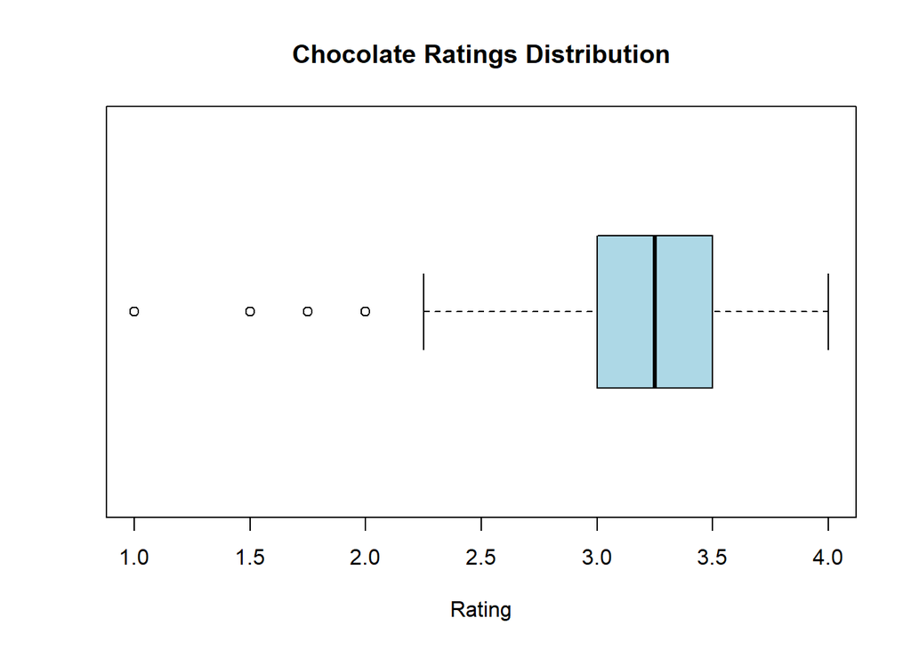

The average of ratings fall between 3.0 and 3.5 on this scale with outliers landing below 2.25.

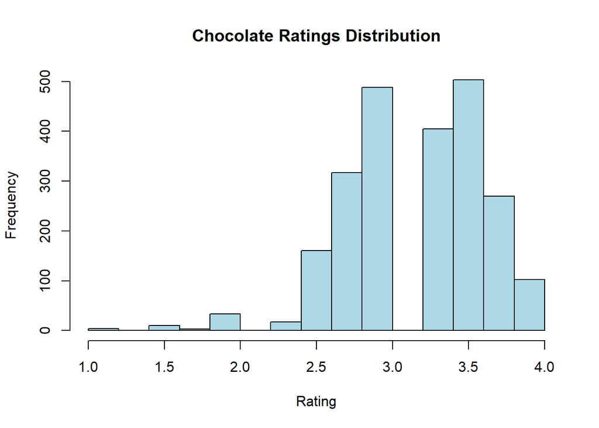

**Question #2**

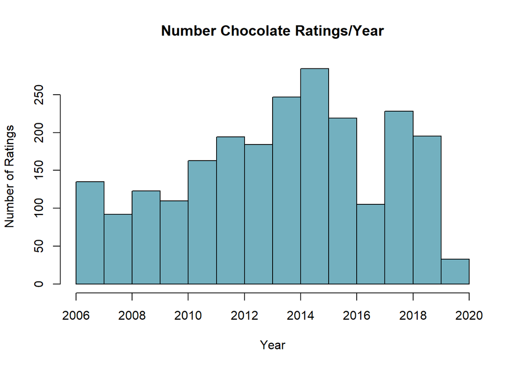

**Question #3**

Correlation Test

```
##
##  Pearson's product-moment correlation
##
## data:  choco$Cocoa_Percent and choco$Rating
## t = -7.3425, df = 2310, p-value = 2.89e-13
## alternative hypothesis: true correlation is not equal to 0
## 95 percent confidence interval:
##  -0.1906101 -0.1109350
## sample estimates:
##        cor
## -0.1510178
```

Visualization

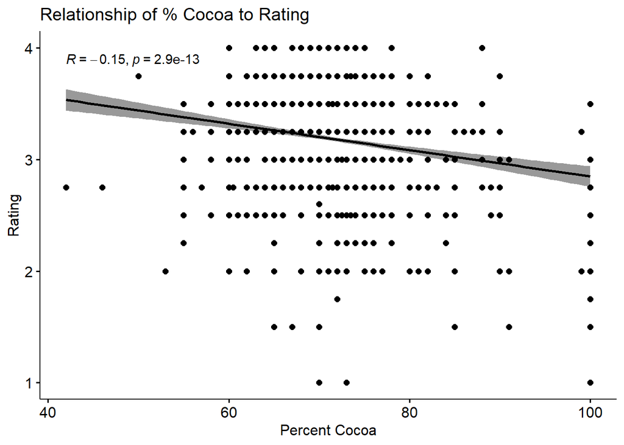

There is weak negative correlation (-.15) between the percent of cocoa in chocolate and the overall rating. The p-value of 2.89e-13 makes this highly significant. This means that higher rated chocolates tend to be less dense in terms of cocoa when compared to added ingredients levels. The greatest variation in ratings occurs in the second and third quartiles.

**Question #4**

[figure not shown]

[figure not shown]

[figure not shown]

[figure not shown]

**Question #5**

1. I’d like to analyze how location of production correlates to ratings. (Which country uses cocoa the best?)
2. I’d like to analyze how country of bean origin correlates to rating. (Which country grows the best cocoa?)